# Results

## Community elevation analysis

Dissimilarity in dipterocarp community compositions reflected by colour variations across the 160 ha plot, extracted from axis 1 of a non-metric multi-dimensional scaling analysis of 12 elevational bands.

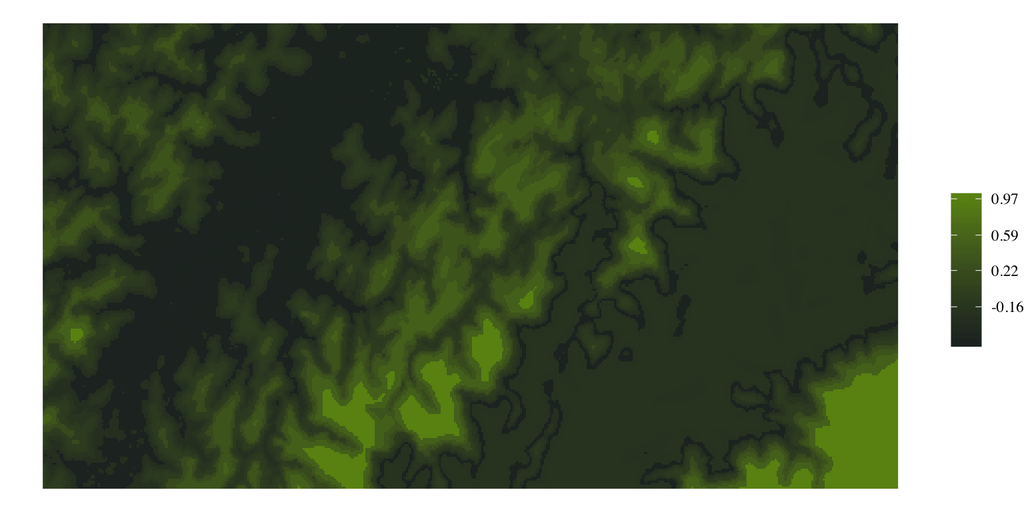

## Species distibution modelling

The elevation distribution of adult dipterocarps within a 160 ha forest plot using the Integrated Nested Laplace Approximation. The 95% credible intervals (n=5000) were extracted from the posterior distribution.

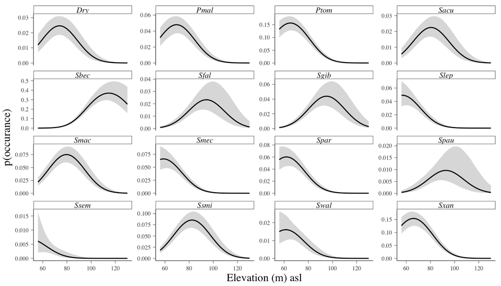

## Species water innundation sensitivity

Species differ in seedling sensitivity to water inundation along micro-topographical gradients within the alluvial zone. Points are ordered by the most likely elevation the adults are found, and grouped by below and above average wood densities for these species. 95% confidence intervals are bootstrapped (n = 5000).

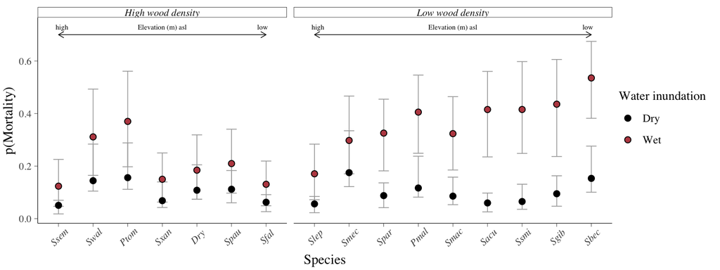

## Species distribution explained by the additive effect of innundation sensitvity and wood density

Multivariate regression of inundation sensitivity (a) and wood density (b) predicting the estimated adult elevation distribution (m). Lines and 95% Confidence intervals were predicted from the model. Red points indicate the raw data, grey points are the partial residuals, and red dashed lines indicate the univariate analysis. Sixteen species were included in the analysis. Percentage variance for each variable from an ANOVA test.

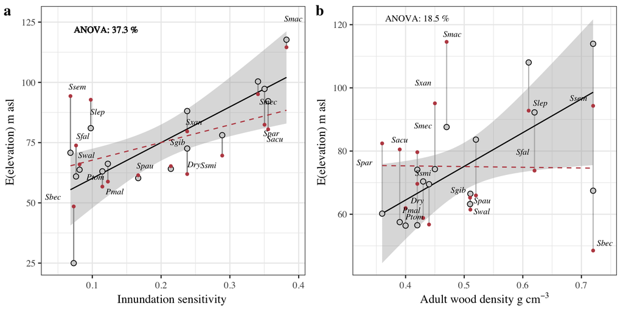

Inundation sensitivity explained 37.3% of interspecific variation in species elevation distribution (βinundation sensitivity = 148.39, 95% CI = 51.53 – 245.24, Fig. 2a), indicating that tolerant individuals occur where areas with inundation episodes. When controlling for inundation, our model predicts that a positive relationship between wood density and elevation (βwood density =106.63, 95% CI = 7.71 – 205.55, anova = 18.5%, Fig. 2b). This suggests that species with high wood density as adults coexist on the alluvial plain and ridge tops partly because of water inundation episodes and droughts.